DS 6030 | Fall 2024 | University of Virginia

# Homework #9: Feature Importance

Author

Courtney Hodge

Published

November 14, 2024

# Required R packages and Directories

```r
dir_data = 'https://mdporter.github.io/teaching/data/' # data directory
library(tidyverse) # functions for data manipulation
```

```r
library(caret)         # For model training and hyperparameter tuning
library(randomForest)  # For Random Forest model
library(ggplot2)       # For plotting
```

# Problem 1: Permutation Feature Importance

Vanderbilt Biostats has collected data on Titanic survivors (https://hbiostat.org/data/). I have done some simple processing and split into a training and test sets.

- titanic_train.csv
- titanic_test.csv

We are going to use this data to investigate feature importance. Use `Class`, `Sex`, `Age`, `Fare`, `sibsp` (number of siblings or spouse on board), `parch` (number of parents or children on board), and `Joined` (city where passenger boarded) for the predictor variables (features) and `Survived` as the outcome variable.

## a. Load the titanic traning and testing data

**Solution**

```r
train <- read.csv("C:\\Users\\hodge\\Desktop\\UVA_Coding_Folder\\DS-6030-Statistical-Learning\\titanic_train.csv")
test <- read.csv("C:\\Users\\hodge\\Desktop\\UVA_Coding_Folder\\DS-6030-Statistical-Learning\\titanic_test.csv")
```

## b. Method 1: Built-in importance scores

Fit a tree ensemble model (e.g., Random Forest, boosted tree) on the training data. You are free to use any method to select the tuning parameters.

Report the built-in feature importance scores and produce a barplot with feature on the x-axis and importance on the y-axis.

**Solution**

```r
#Handle missing values
train$Age[is.na(train$Age)] <- median(train$Age, na.rm = TRUE)
test$Age[is.na(test$Age)] <- median(test$Age, na.rm = TRUE)

# Fill missing values in numeric columns with the median
train$Age[is.na(train$Age)] <- median(train$Age, na.rm = TRUE)
train$Fare[is.na(train$Fare)] <- median(train$Fare, na.rm = TRUE)
test$Age[is.na(test$Age)] <- median(test$Age, na.rm = TRUE)
test$Fare[is.na(test$Fare)] <- median(test$Fare, na.rm = TRUE)

# Convert categorical variables to factors
train$Class <- factor(train$Class)
train$Sex <- factor(train$Sex)
train$Joined <- factor(train$Joined)

test$Class <- factor(test$Class)
test$Sex <- factor(test$Sex)
test$Joined <- factor(test$Joined)
```

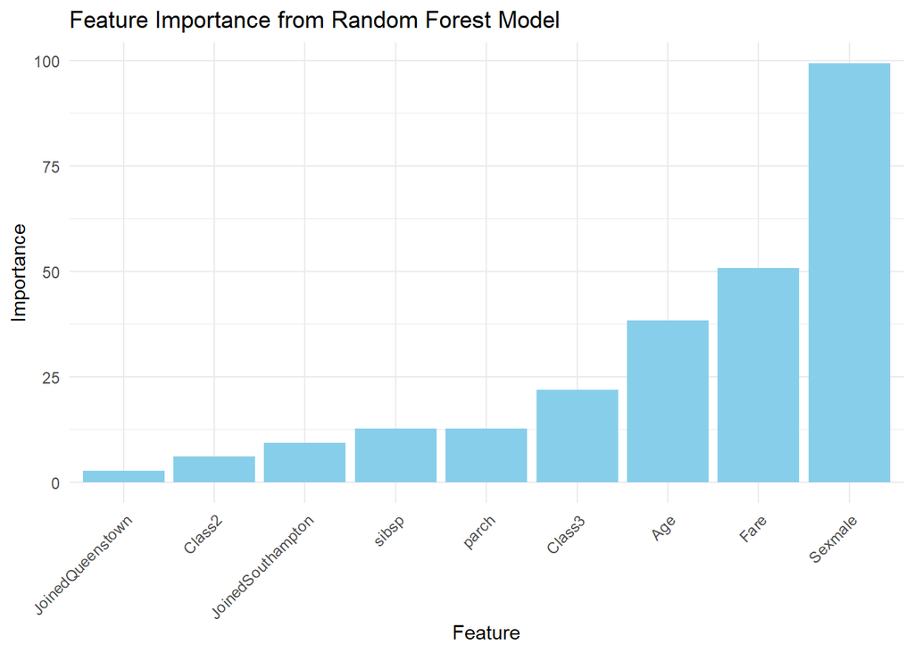

```r
#Fitting a Random Forst Model
predictors <- c("Class", "Sex", "Age", "Fare", "sibsp", "parch", "Joined")
outcome <- "Survived"

# Convert Survived to a factor to ensure classification mode
train$Survived <- factor(train$Survived)
test$Survived <- factor(test$Survived)


# training control for cross-validation
train_control <- trainControl(method = "cv", number = 5)

# Fit the Random Forest model again, ensuring that it's a classification model
set.seed(42)
rf_model <- train(
  Survived ~ .,
  data = train[, c(outcome, predictors)],
  method = "rf",
  trControl = train_control,
  tuneLength = 5  # This will test 5 different tuning parameters
)


# Get the variable importance from the final model
importance <- varImp(rf_model, scale = FALSE)
importance_df <- as.data.frame(importance$importance)
importance_df$Feature <- rownames(importance_df)
importance_df <- importance_df %>% arrange(desc(Overall))

#Plot Feature Importance
ggplot(importance_df, aes(x = reorder(Feature, Overall), y = Overall)) +
  geom_bar(stat = "identity", fill = "skyblue") +
  labs(title = "Feature Importance from Random Forest Model",
       x = "Feature",
       y = "Importance") +
  theme_minimal() +
  theme(axis.text.x = element_text(angle = 45, hjust = 1))
```

```r
#print the feature importance score
print(importance_df)
```

```
                  Overall           Feature
Sexmale             99.42           Sexmale
Fare                50.70              Fare
Age                 38.29               Age
Class3              21.94            Class3
parch               12.74             parch
sibsp               12.62             sibsp
JoinedSouthampton    9.38 JoinedSouthampton
Class2               6.12            Class2
JoinedQueenstown     2.63  JoinedQueenstown
```

## c. Performance

Report the performance of the model fit from (a.) on the test data. Use the log-loss (where $M$ is the size of the test data):
$$\text{log-loss}(\hat{p}) = - \frac{1}{M} \sum_{i=1}^m [y_i \log \, \hat{p}_i + (1 - y_i) \log \, (1 - \hat{p}_i)]$$

**Solution**

```r
# Define a small constant to avoid log(0)
epsilon <- 1e-15

# Predict probabilities on the test set
test_probs <- predict(rf_model, newdata = test[, predictors], type = "prob")

# Extract probabilities for the survival class '1'
p_hat <- test_probs[, "1"]  # assuming "1" is the label for survived

# Get the actual survival status from the test data
y_test <- as.numeric(as.character(test$Survived))  # Convert factor to numeric 0 and 1

# Apply epsilon adjustment to probabilities
p_hat <- pmax(epsilon, pmin(1 - epsilon, p_hat))  # Ensures probabilities are between epsilon and 1 - epsilon

# Calculate log-loss manually
M <- length(y_test)  # Number of observations in the test set
log_loss <- -mean(y_test * log(p_hat) + (1 - y_test) * log(1 - p_hat))

# Print the log-loss result
print(paste("Log-Loss on test data:", round(log_loss, 4)))
```

```
[1] "Log-Loss on test data: 0.5038"
```

## d. Method 2: Permute *after* fitting

Use the fitted model from question (a.) to perform permutation feature importance. Shuffle/permute each variable individually on the *test set* before making predictions. Record the loss. Repeat $M=10$ times and produce a boxplot of the change in loss (change from reported loss from part b.).

**Solution**

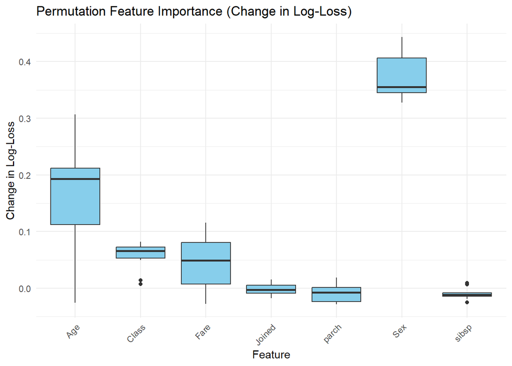

```r
# Define the small constant epsilon used for log-loss calculations
epsilon <- 1e-15

# Calculate the baseline log-loss on the original test set
test_probs <- predict(rf_model, newdata = test[, predictors], type = "prob")
p_hat <- test_probs[, "1"]
p_hat <- pmax(epsilon, pmin(1 - epsilon, p_hat))  # Apply epsilon adjustment
y_test <- as.numeric(as.character(test$Survived))
baseline_log_loss <- -mean(y_test * log(p_hat) + (1 - y_test) * log(1 - p_hat))

#Perform Permutation Feature Importance
set.seed(42)  # Set seed for reproducibility
M <- 10       # Number of permutations
features <- predictors
perm_importance <- data.frame(Feature = character(), Loss = numeric(), stringsAsFactors = FALSE)

# Loop over each feature for permutation
for (feature in features) {
  losses <- numeric(M)  # Store log-losses for this feature

  for (m in 1:M) {
    # Step 3: Permute the feature
    permuted_test <- test  # Copy test data
    permuted_test[[feature]] <- sample(permuted_test[[feature]])  # Shuffle the feature

    # Predict probabilities on permuted data
    permuted_probs <- predict(rf_model, newdata = permuted_test[, predictors], type = "prob")
    permuted_p_hat <- permuted_probs[, "1"]
    permuted_p_hat <- pmax(epsilon, pmin(1 - epsilon, permuted_p_hat))  # Apply epsilon adjustment

    # Calculate log-loss for permuted data
    permuted_log_loss <- -mean(y_test * log(permuted_p_hat) + (1 - y_test) * log(1 - permuted_p_hat))

    # Record the loss
    losses[m] <- permuted_log_loss
  }

  # Calculate change in log-loss and store in the results data frame
  delta_loss <- losses - baseline_log_loss
  perm_importance <- rbind(perm_importance, data.frame(Feature = feature, Loss = delta_loss))
}

# Plot the permutation feature importance as a boxplot
library(ggplot2)

ggplot(perm_importance, aes(x = Feature, y = Loss)) +
  geom_boxplot(fill = "skyblue") +
  labs(title = "Permutation Feature Importance (Change in Log-Loss)",
       x = "Feature",
       y = "Change in Log-Loss") +
  theme_minimal() +
  theme(axis.text.x = element_text(angle = 45, hjust = 1))
```

## e. Method 3: Permute *before* fitting

For this approach, shuffle/permute the *training data* and re-fit the ensemble model. Evaluate the predictions on the (unaltered) test data. Repeat $M=10$ times (for each predictor variable) and produce a boxplot of the change in loss.

**Solution**

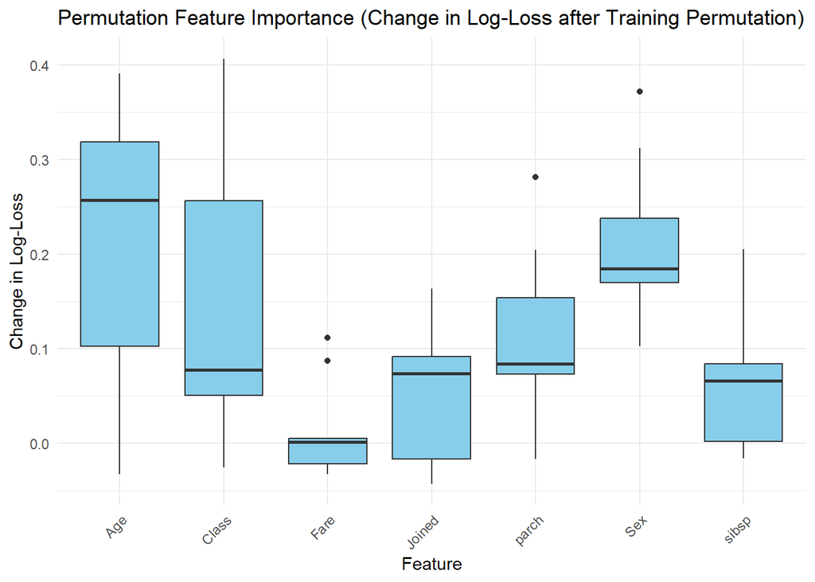

```r
# Define epsilon to avoid log(0) issues in log-loss calculation
epsilon <- 1e-15

#Calculate baseline log-loss on the unaltered test set using the original model
test_probs <- predict(rf_model, newdata = test[, predictors], type = "prob")
p_hat <- test_probs[, "1"]
p_hat <- pmax(epsilon, pmin(1 - epsilon, p_hat))  # Apply epsilon adjustment
y_test <- as.numeric(as.character(test$Survived))
baseline_log_loss <- -mean(y_test * log(p_hat) + (1 - y_test) * log(1 - p_hat))

#Perform feature permutation in the training data and re-fit model
set.seed(42)  # For reproducibility
M <- 10       # Number of repetitions for each feature permutation
features <- predictors
perm_train_importance <- data.frame(Feature = character(), Loss = numeric(), stringsAsFactors = FALSE)

for (feature in features) {
  losses <- numeric(M)  # Store log-losses for this feature

  for (m in 1:M) {
    # Shuffle the feature in the training data
    permuted_train <- train  # Copy training data
    permuted_train[[feature]] <- sample(permuted_train[[feature]])  # Permute the feature in training

    #Re-fit the model with the permuted training data
    perm_rf_model <- train(
      Survived ~ .,
      data = permuted_train[, c(outcome, predictors)],
      method = "rf",
      trControl = train_control,
      tuneLength = 5  # Use same tuning length as original
    )

    # Predict probabilities on the unaltered test data
    perm_test_probs <- predict(perm_rf_model, newdata = test[, predictors], type = "prob")
    perm_p_hat <- perm_test_probs[, "1"]
    perm_p_hat <- pmax(epsilon, pmin(1 - epsilon, perm_p_hat))  # Apply epsilon adjustment

    # Calculate log-loss for permuted model on test data
    perm_log_loss <- -mean(y_test * log(perm_p_hat) + (1 - y_test) * log(1 - perm_p_hat))

    # Record the log-loss
    losses[m] <- perm_log_loss
  }

  # Calculate the change in log-loss and store in the results data frame
  delta_loss <- losses - baseline_log_loss
  perm_train_importance <- rbind(perm_train_importance, data.frame(Feature = feature, Loss = delta_loss))
}

#Plot the permutation feature importance as a boxplot
library(ggplot2)

ggplot(perm_train_importance, aes(x = Feature, y = Loss)) +
  geom_boxplot(fill = "skyblue") +
  labs(title = "Permutation Feature Importance (Change in Log-Loss after Training Permutation)",
       x = "Feature",
       y = "Change in Log-Loss") +
  theme_minimal() +
  theme(axis.text.x = element_text(angle = 45, hjust = 1))
```

## f. Understanding

Describe the benefits of each of the three approaches to measure feature importance.

**Solution**

> Built-in Feature Importance: is efficient and quick and provides an understanding of feature contribution directly from the model.

> Permutation on Test Data: provides a robust, model-agnostic view of feature importance based on test performance, helping to evalute the generalization impact of each feature.

> Permutation with Model Re-Fitting: assess the influence of each feature on the model’s learning process, offering insights into the stability and significance of features during training.

# Problem 2: Effects of correlated predictors

This problem will illustrate what happens to the importance scores when there are highly associated predictors.

## a. Create an almost duplicate feature

**Solution**

```r
set.seed(42)  # For reproducibility

# Make a copy of the `Sex` column to create `Sex2`
train$Sex2 <- train$Sex
test$Sex2 <- test$Sex

# Calculate the number of rows to flip in training and test sets (5%)
n_train <- nrow(train)
n_test <- nrow(test)
n_flip_train <- round(0.05 * n_train)
n_flip_test <- round(0.05 * n_test)

# Randomly select 5% of the rows in the training set and flip the `Sex2` value
train_flip_indices <- sample(1:n_train, n_flip_train)
train$Sex2[train_flip_indices] <- ifelse(train$Sex[train_flip_indices] == "Male", "Female", "Male")
# Randomly select 5% of the rows in the test set and flip the `Sex2` value
test_flip_indices <- sample(1:n_test, n_flip_test)
test$Sex2[test_flip_indices] <- ifelse(test$Sex[test_flip_indices] == "Male", "Female", "Male")
# Verify the changes
print(table(train$Sex, train$Sex2))  # Check consistency in training
```

```
         female male
  female    341    0
  male        0  617
```

```r
print(table(test$Sex, test$Sex2))    # Check consistency in testing
```

```
         female male
  female    104    0
  male        0  182
```

## b. Method 1: Built-in importance

Fit the same model as in Problem 1b, but use the new data that includes `Sex2` (i.e., use both `Sex` and `Sex2` in the model). Calculate the built-in feature importance score and produce a barplot.

**Solution**

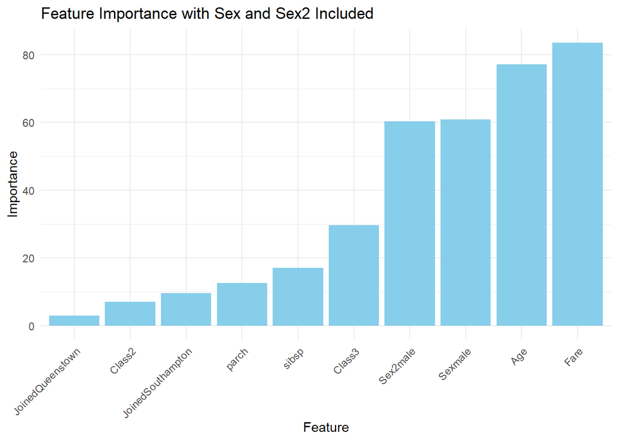

```r
# Ensure necessary libraries are loaded
library(caret)
library(ggplot2)
library(dplyr)

# Update predictors to include Sex2
predictors <- c("Class", "Sex", "Age", "Fare", "sibsp", "parch", "Joined", "Sex2")
outcome <- "Survived"

# Ensure that we are selecting only the necessary columns and remove rows with any NA values
train_clean <- train %>%
  select(all_of(c(outcome, predictors))) %>%
  drop_na()  # This will drop rows with any NA values

test_clean <- test %>%
  select(all_of(c(outcome, predictors))) %>%
  drop_na()  # Drop rows with any NA values in the test set

# Fit the Random Forest model again with the updated predictors
rf_model_sex2 <- train(
  Survived ~ .,
  data = train_clean,  # Use train_clean with selected columns
  method = "rf",
  trControl = train_control,
  tuneLength = 5  # Use the same tuning length as in previous parts
)

# Calculate built-in feature importance
importance_sex2 <- varImp(rf_model_sex2, scale = FALSE)
importance_df_sex2 <- as.data.frame(importance_sex2$importance)
importance_df_sex2$Feature <- rownames(importance_df_sex2)
importance_df_sex2 <- importance_df_sex2 %>% arrange(desc(Overall))

# Plot the feature importance
ggplot(importance_df_sex2, aes(x = reorder(Feature, Overall), y = Overall)) +
  geom_bar(stat = "identity", fill = "skyblue") +
  labs(title = "Feature Importance with Sex and Sex2 Included",
       x = "Feature",
       y = "Importance") +
  theme_minimal() +
  theme(axis.text.x = element_text(angle = 45, hjust = 1))
```

## c. Method 2: Permute *after* fitting

Redo Method 2 (problem 1d) on the new data/model and produce a boxplot of importance scores. The importance score is defined as the difference in loss.

**Solution**

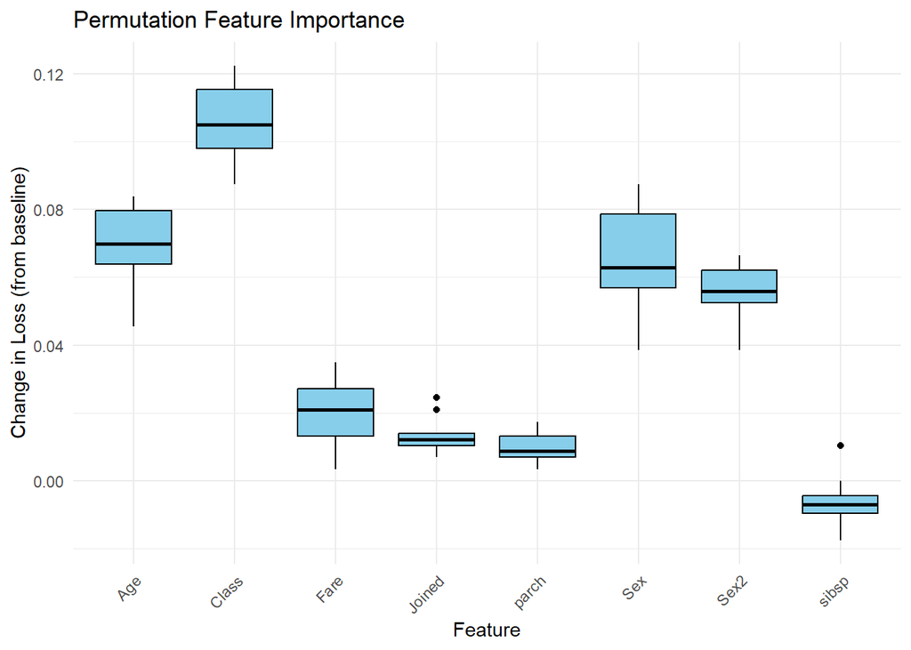

```r
library(caret)
library(ggplot2)
library(dplyr)
library(randomForest)

# Define loss function (e.g., accuracy or any other loss metric you prefer)
calculate_loss <- function(model, test_data, outcome) {
  predictions <- predict(model, newdata = test_data, type = "raw")  # Use type = "raw" to get predicted classes
  accuracy <- mean(predictions == test_data[[outcome]])
  return(1 - accuracy)  # We use 1 - accuracy as the loss metric
}

# Get the baseline loss on the test set
baseline_loss <- calculate_loss(rf_model_sex2, test_clean, outcome)

# Number of permutations
M <- 10
loss_changes <- data.frame(Feature = character(), Loss_Change = numeric())

# Loop through each feature and permute it
for (feature in predictors) {

  feature_losses <- numeric(M)

  for (i in 1:M) {

    # Create a permuted version of the test set by shuffling the feature column
    test_permuted <- test_clean
    test_permuted[[feature]] <- sample(test_permuted[[feature]])

    # Calculate the loss on the permuted test set
    permuted_loss <- calculate_loss(rf_model_sex2, test_permuted, outcome)

    # Store the difference in loss
    feature_losses[i] <- permuted_loss - baseline_loss
  }

  # Store the results for this feature
  loss_changes <- rbind(loss_changes, data.frame(Feature = feature, Loss_Change = feature_losses))
}

# Boxplot of feature importance (change in loss)
ggplot(loss_changes, aes(x = Feature, y = Loss_Change)) +
  geom_boxplot(fill = "skyblue", color = "black") +
  labs(title = "Permutation Feature Importance",
       x = "Feature",
       y = "Change in Loss (from baseline)") +
  theme_minimal() +
  theme(axis.text.x = element_text(angle = 45, hjust = 1))
```

## d. Method 3: Permute *before* fitting

Redo Method 3 (problem 1e) on the new data and produce a boxplot of importance scores. The importance score is defined as the difference in loss.

**Solution**

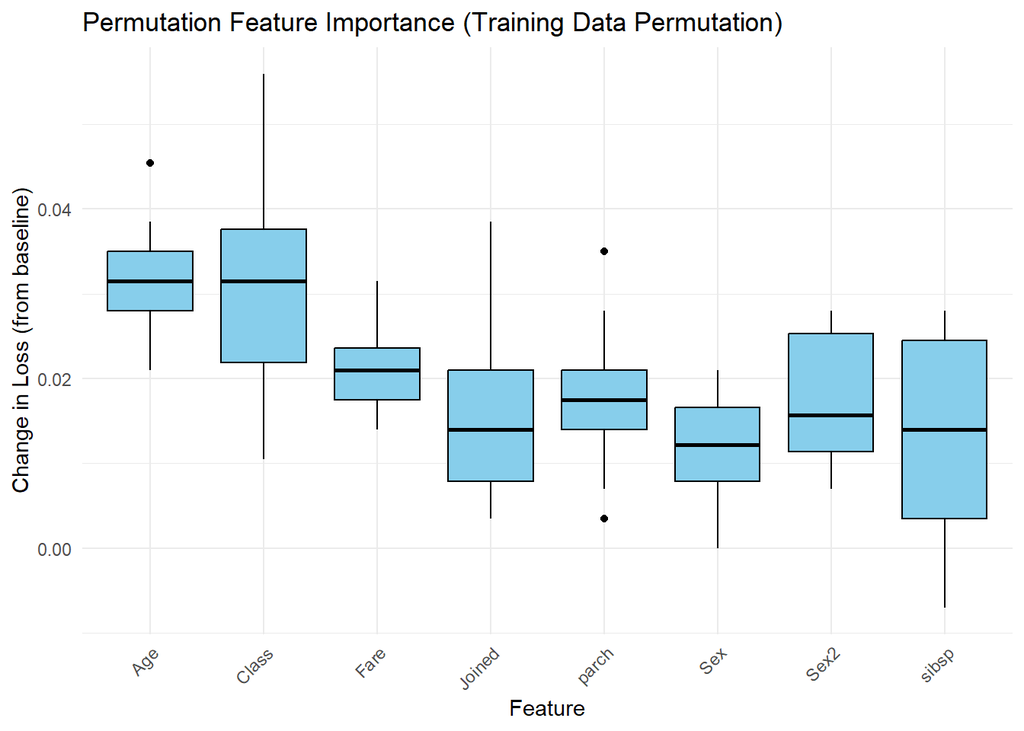

```r
library(caret)
library(ggplot2)
library(dplyr)
library(randomForest)

# Define loss function (e.g., accuracy or any other loss metric you prefer)
calculate_loss <- function(model, test_data, outcome) {
  predictions <- predict(model, newdata = test_data, type = "raw")  # Use type = "raw" to get predicted classes
  accuracy <- mean(predictions == test_data[[outcome]])
  return(1 - accuracy)  # We use 1 - accuracy as the loss metric
}

# Get the baseline loss on the test set (using original training data)
baseline_loss <- calculate_loss(rf_model_sex2, test_clean, outcome)

# Number of permutations (10 times per feature)
M <- 10
loss_changes <- data.frame(Feature = character(), Loss_Change = numeric())

# Loop through each feature and permute it in the training set
for (feature in predictors) {

  feature_losses <- numeric(M)

  for (i in 1:M) {

    # Shuffle the feature values in the training data
    train_permuted <- train_clean
    train_permuted[[feature]] <- sample(train_permuted[[feature]])

    # Refit the random forest model using the permuted training data
    rf_model_permuted <- train(
      Survived ~ .,
      data = train_permuted,  # Use permuted training data
      method = "rf",
      trControl = train_control,
      tuneLength = 5
    )

    # Calculate the loss on the unaltered test data
    permuted_loss <- calculate_loss(rf_model_permuted, test_clean, outcome)

    # Store the difference in loss from the baseline
    feature_losses[i] <- permuted_loss - baseline_loss
  }

  # Store the results for this feature
  loss_changes <- rbind(loss_changes, data.frame(Feature = feature, Loss_Change = feature_losses))
}

# Boxplot of feature importance (change in loss)
ggplot(loss_changes, aes(x = Feature, y = Loss_Change)) +
  geom_boxplot(fill = "skyblue", color = "black") +
  labs(title = "Permutation Feature Importance (Training Data Permutation)",
       x = "Feature",
       y = "Change in Loss (from baseline)") +
  theme_minimal() +
  theme(axis.text.x = element_text(angle = 45, hjust = 1))
```

## e. Understanding

Describe how the addition of the almost duplicated predictor impacted the feature importance results.